# Meta-trend analysis

## Methodology

1. So far we have collected data for the past three weeks -- '200329', '200405', '200412' (for example, 200329 means we queried URLs collected from 03/22/20 to 03/29/20).
2. The end query date is **April 14, 2020** for all three datasets, because there werer some issues with URL formatting and I reran all analysis all that day. As a result, posts from 200329 dataset will last longer than 200405, which will last longer than 200412. **This is an artifact of our data collection process**.
3. For each statistics, we look at how it changes as a function of time

### Discoverability analysis (what percentage of URLs are searchable on each platform)

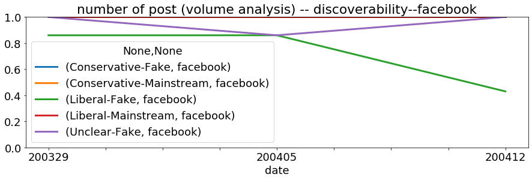

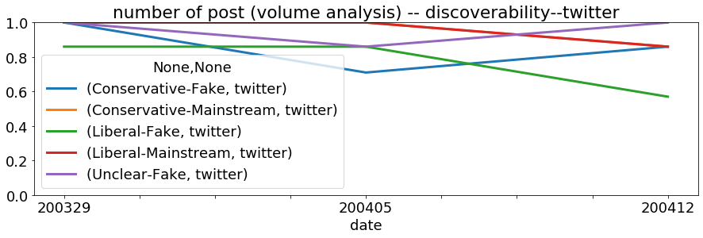

[figure not shown]

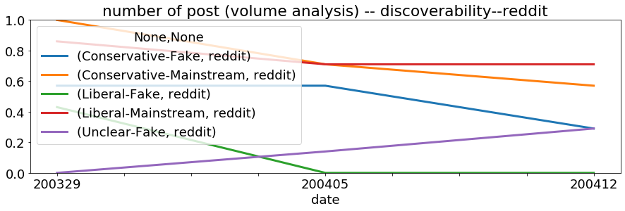

### User volume analysis

- Among all sources, **mainstream liberal** is posted by the most number of users
- If we look at fake sources, more users tweet **conservative fake** than liberal fake
- Few verified users tweet **fake** source

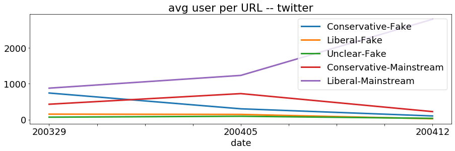

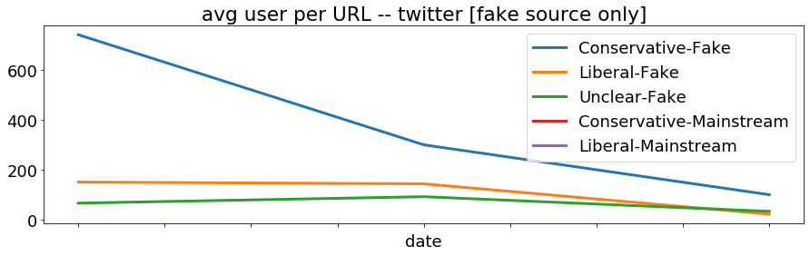

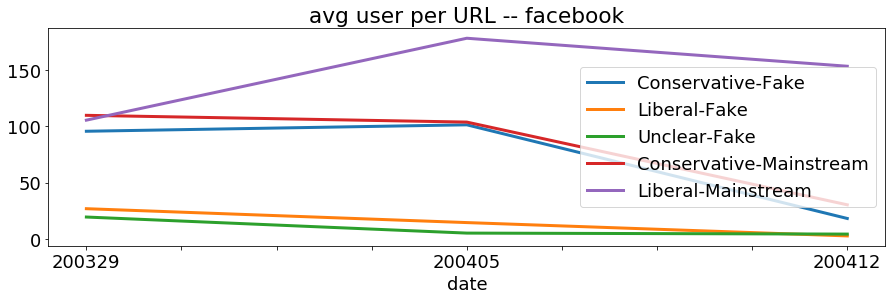

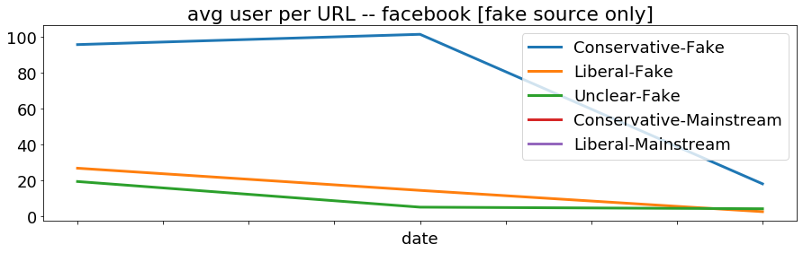

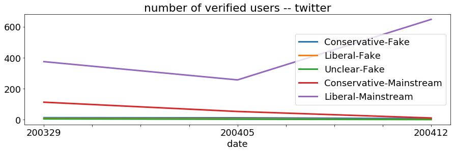

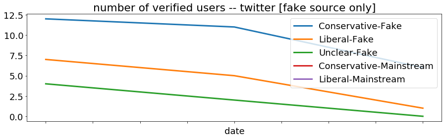

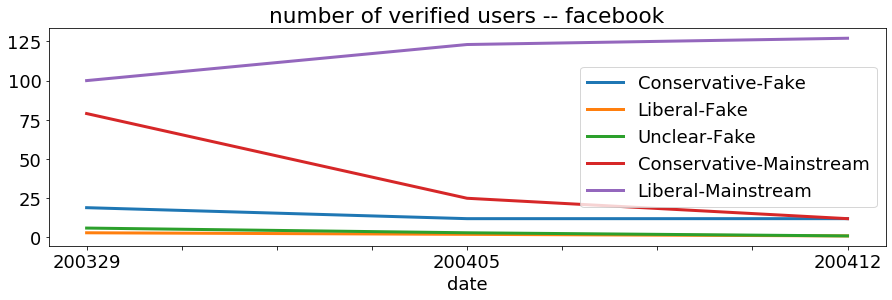

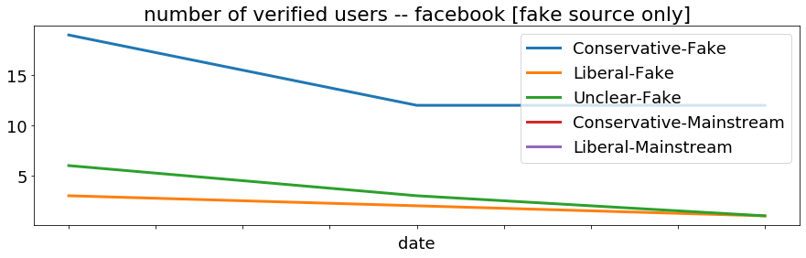

### Longivity analysis

- longivity = number of hours between first post and last post
- longivity has high variance, but overall (both in mean and median), **conservative fake posts spread longer** than liberal fake (this is true on all three weeks, and on both platforms)

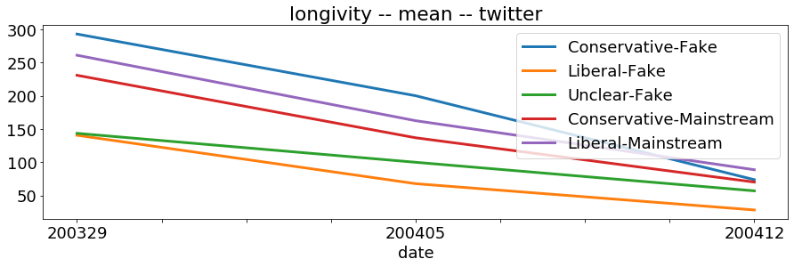

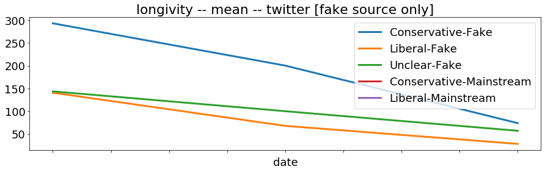

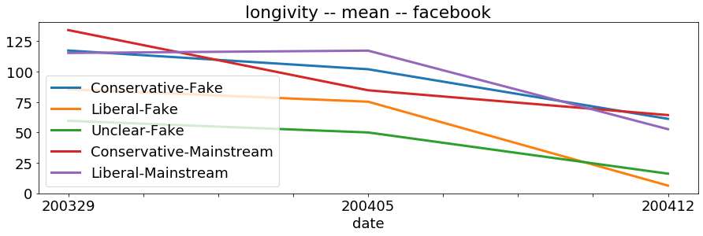

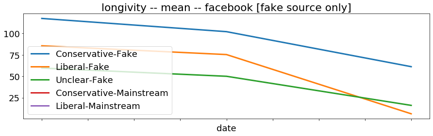

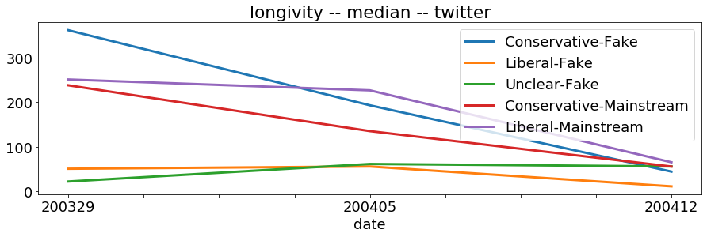

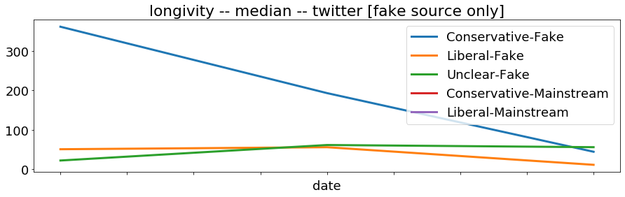

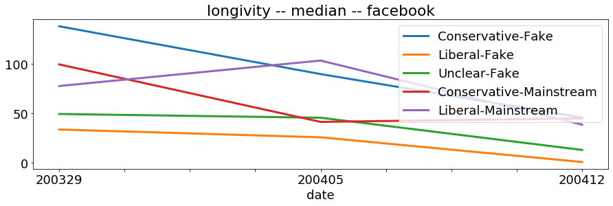

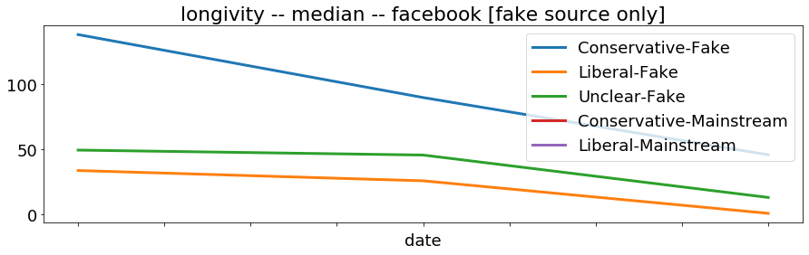

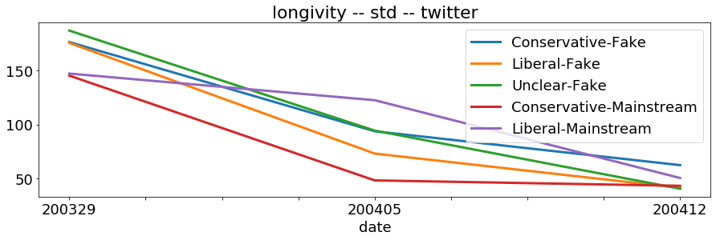

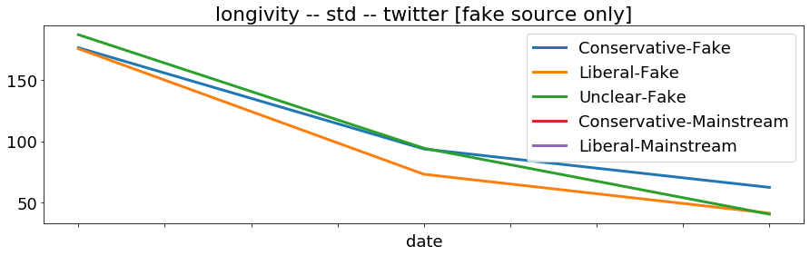

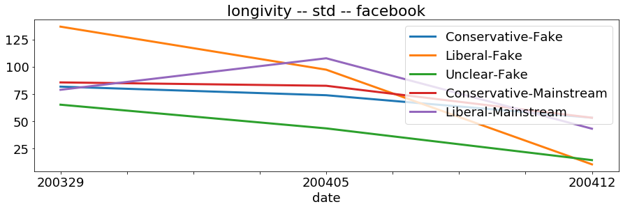

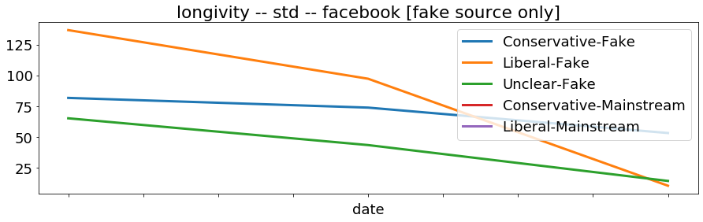